# ME8135 - FINAL PROJECT

Hira Fatima

April 7, 2017

## DESCRIPTION OF THE PROBLEM

> As part of the final project for Data Visualization course, I wanted to use visualizations to summarize data that was otherwise difficult to interpret. I found the perfect problem to solve with the 12 datasets available on Government of Ontario’s Data Catalogue which have the information for the Ontario universities, but it is nearly impossible to draw any conclusions from that data by just going through the files manually.

> The goal of this project is to transform those files into meaningful visualizations that would speak for themselves and tell a complete story about the universities in Ontario!

## DATA SOURCE

> The datasets that I have used in this project are taken from the Government of Ontario website. [LINK](https://www.ontario.ca/search/data-catalogue?sort=asc) Government of Ontario has a Data Catalogue with public datasets available related to the province of Ontario. From this catalogue, I have chosen 12 datasets related to University Enrollment in the province of Ontario. These datasets contain

> “Enrolment and Statistical data for universities in the province that receive regular operating funding from the Ministry of Training, Colleges and Universities.[Datasets] provide aggregated key enrolment data for university students, such as:
> - enrolment headcounts by program type, institution and campus
> - enrolment by student status (e.g., domestic, international, citizenship) by institution
> - enrolment by prior education activity and level of study by institution
> - enrolment by credentials pursued/registration status
> - student characteristics (e.g., gender, age, first language)
> - student status by institution by province, country of residence."

> Here is a table with complete details of each dataset.

| File | Name Fields |
| --- | --- |
| Head Count by Program Major | UNIVERSITY, PROGRAMS SPEMAJ, HEAD COUNT |
| Head Count by Age Group | UNIVERSITY, AGE GROUP , HEAD COUNT |
| Head Count by Campus | UNIVERSITY, CAMPUS, HEAD COUNT |
| Head Count by Country of Citizenship | UNIVERSITY, COUNTRY OF CITIZENSHIP, HEAD COUNT |
| Head Count by Program of Study | UNIVERSITY, PROGRAM FORPOS, HEAD COUNT |
| Head Count by Gender | UNIVERSITY, GENDER, HEAD COUNT |
| Head Count by Immigration Status | UNIVERSITY, IMMIGRATION STATUS, HEAD COUNT |
| Head Count by Level of Study | UNIVERSITY, LEVEL OF STUDY, HEAD COUNT |
| Head Count by Mother Tongue | UNIVERSITY, MOTHER TONGUE, HEAD COUNT |
| Head Count by Province of Residence | UNIVERSITY, PROVINCE OF RESIDENCE, HEAD COUNT |
| Head Count by Registration Status | UNIVERSITY, REGISTRATION STATUS, HEAD COUNT |
| Head Count by Year of Study | UNIVERSITY, YEAR OF STUDY, HEAD COUNT |

> References to these datasets are provided in the next section.

## REFERENCES

> Here is the [LINK](https://www.ontario.ca/data/university-enrolment) where the datasets were downloaded from.

## TECHNOLOGIES USED

> R Programming and R Studio were the main software used for progamming this project. The most important library used was PLOTLY [LINK](https://plot.ly/). Plotly provides a lot of capabilites from creating interactive graphs (as it uses D3 under the hood) to online dashboards and also the abililty to import these interactive graphs in PowerPoint Presentations. For this reason, I primarily used Plotly to create my graphs. Ploly works in conjunction with GGPLOT2 [LINK](http://ggplot2.org/), which was my second main library used to create the graphs.

> This final output file was created using R MARKDOWN [LINK](https://www.rstudio.com/wp-content/uploads/2015/03/rmarkdown-reference.pdf).

> There were some other libraries that I used to addition to these two as listed below for further analytics and formatting of graphs. Most notable one here would be RWORLDMAP [LINK](https://journal.r-project.org/archive/2011-1/RJournal_2011-1_South.pdf), taken from a journal paper called “rworldmap: A New R package for Mapping Global Data”.
> - maps
> - mapsproj
> - readr
> - XML
> - reshape2
> - plyr
> - sp
> - rworldmap

## PREPROCESSING ON DATA

> Since there was a huge variance in head counts, the numbers were normalized to ensure correct interpretations were rendered with each visualization. For instance, although the University of Ottawa shows a higher proportion of French students, it is was primarily because overall University of Ottawa does have more students than Dominician. After normalization, it was clear that although there were much less students in Dominician University, the share of French students is much higher than University of Ottawa.

> Other preprocessing details included some other calculation to prepare the data for plotting (e.g. aggregation) or changing some column formats to factor or numbers.

## VISUALIZATIONS

…

> **Don’t forget to hover over the visualizations for more details!**

…

> Let’s start off by looking at how many universities are there in Ontario and what their total head counts are. Please note that the data was retreived for acedamic year 2012-2013 so all the numbers reported here are for that time frame.

…

> In the graph below, the universities are ordered by headcount. University of Toronto takes a lead here followed by York University and University of Ottawa.

[interactive chart not shown]

…

> Below is a screenshot of the same graph reproduced using D3.

image:

[figure not shown]

> The counts above represent totals for each University. Most of these universities have more than 1 campuses. Let’s take a look at how many campuses does each of them have.

> The table snippet below contains information of all universities with their campuses and headcounts at each campus.

```
##   UNIVERSITY                             CAMPUS HEADCOUNT
## 1     Algoma                  Algoma University      1106
## 2      Brock         Brock College of Education       325
## 3      Brock                   Brock University     15198
## 4      Brock Brock University - Hamilton Campus       331
## 5   Carleton                Carleton University     22436
## 6     Guelph                 Kemptville College       201
```

…

> The average number of campuses per university was calculated as follows.

```
## [1] 2.363636
```

…

> As shown above, on average, universities have 2-3 campuses each. Waterloo has the highest number at 5. The results are shown in a plot below.

[interactive chart not shown]

…

> How about we now check to see where most of the students to these universities come from?

…

> It is clear from the graph above that although 91% of the students are domestic, 9% students are international students.

[interactive chart not shown]

…

> Why don’t we check to see where the international students come from, as in which part of the world?

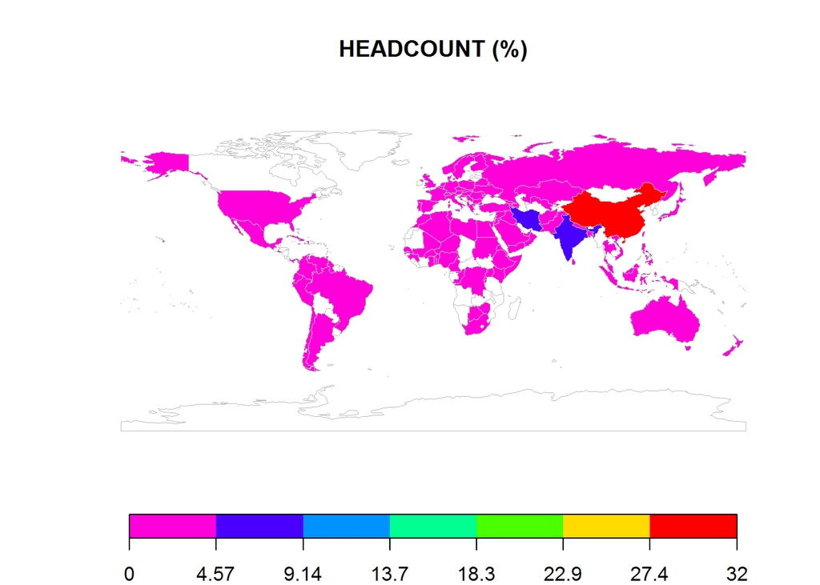

…

> As shown in the world map, majority of the students come from China followed by India and Iran. The bar chart below provides the international student distribution in percentage for top 6 countries.

[interactive chart not shown]

> **Reminder: Don’t forget to hover over the visualizations for more details!** ***

…

> How about we now look at where the domestic students come from? We already know 91% of the students are domestic, of which, majority do belong to the province of Ontario as shown below.

[interactive chart not shown]

…

> If we exclude these students from Ontario and zoom into other provinces, Quebec and British Columbia take the lead. Any idea what ‘Not Applicable’ refers to? International students, perhaps!

[interactive chart not shown]

…

> Why don’t we take a look at the mother tongue distribution for these universities? After all Canada is a bilingual country!

[interactive chart not shown]

…

> The graph above shows that Ottawa has the highest number of French students. Let’s look at a normalized version of the same graph to make sure!

[interactive chart not shown]

…

> Well, based on the normalized graph, in addition to University of Ottawa, there are two more that also have a considerably higher number of French students, namely, Laurentian and Dominician.

…

> How about we look at demographics more closely now? Let’s start with gender.

[interactive chart not shown]

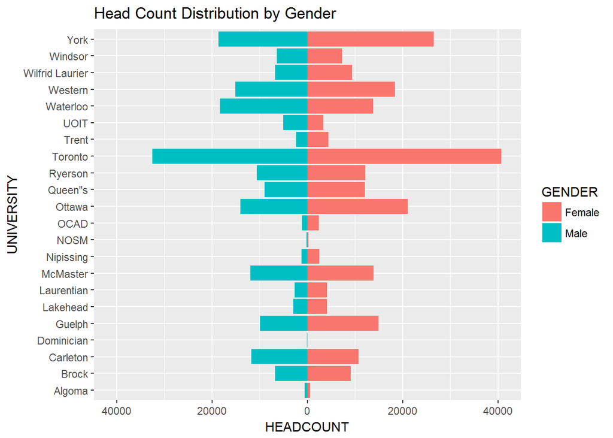

…

> Although there is a fair distribution of males versus females, there are slightly more females attending universities than males. Since there are more females in the world than males in general, it makes sense that such is the case at Ontario universities as well!

…

> And now let’s move on to age group.

…

> Here is a distribution (count) per university by age group.

[interactive chart not shown]

…

> However, it would make more sense to look at a normalized graph as shown below. 18-24 is the most popular age group since an undergraduate degree is a natural progression after high school. NOSM (Northern Ontario School of Medicine) has a highest portion of students in the 25-34 age group, primarily because it is a specialized medical institution.

[interactive chart not shown]

…

> It is now time to look at the student distribution by registration status.

…

> Portion of students with a full-time status is obviously higher for all universities. Ryerson University and Nipissing University have the highest proportion of part-time students compared to others.

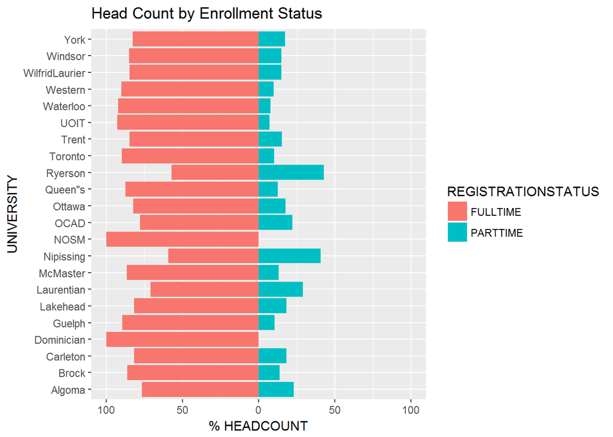

…

> Let’s move on to Level of Study. Here is the head count distribution by level of study.

[interactive chart not shown]

…

> Since there is a huge variance in the head count distribution, why don’t we look at a normalized version. A normalized version shows that NOSM (Northern Ontario School of Medicine) has the highest number of undergraduate diploma students.

[interactive chart not shown]

…

> And here is another way of looking at the same data (normalized head count distribution by level of study)!

[interactive chart not shown]

…

> How about we break it down further and look at the head count by year of study?

…

> As usual, here is a plot of head counts by level of study.

[interactive chart not shown]

…

> And here is a normalized version. Since we already saw that majority of the students enrolled are at their undergraduate level of study in the earlier graph, it makes sense that we see the same trend here. Majority of the students are in their 1st to 4th year of study.

[interactive chart not shown]

…

> Last but not the least, let’s looks at the top 10 popular programs at these universities.

…

> Business programs are a clear winner with 13% share as the most popular choice followed by Psychology and General Arts.

[interactive chart not shown]

…

> We looked at the top 10. It wouldn’t be fair to leave out the bottom 10.

[interactive chart not shown]

## LESSONS LEARNED

> It was great excercise to put all the concepts of data visualization learned in class to practice as part of this project. In a matter of days, I learned so many new things from how to publish plotly charts on their website and then including the interactive versions in PowerPoint presentations to creating RMarkdown reports. Generating the report using RMarkdown was the most rewarding experience because it will allow my audience to actually use the interactive graph capabilities provided by Plotly.